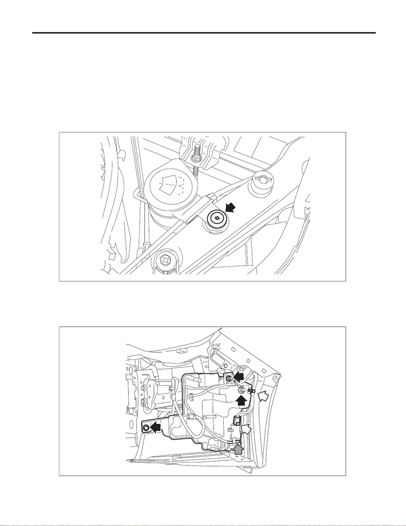

WW-14

Washer Tank and Motor

WIPER AND WASHER SYSTEMS

6. Washer Tank and Motor

A: REMOVAL

1. WASHER TANK

1) Disconnect the ground cable from battery. <Ref. to NT-5, BATTERY, NOTE, Note.>

NOTE:

For models other than STI model, disconnect the ground terminal from battery sensor.

2) Remove the bumper face - front. <Ref. to EI-30, REMOVAL, Front Bumper.>

3) Remove the tank - washer assembly.

(1) Remove the clip of the holder - windshield washer tank.

(2) Disconnect the connector from the motor pump assembly - washer and the sensor - washer tank, and

then remove the harness clip.

(3) Prepare a container before disconnecting the hose - washer, and drain all washer fluid in the tank -

washer.

(4) Remove the bolt and nuts and remove the tank - washer assembly.

WW-00821

WW-01163

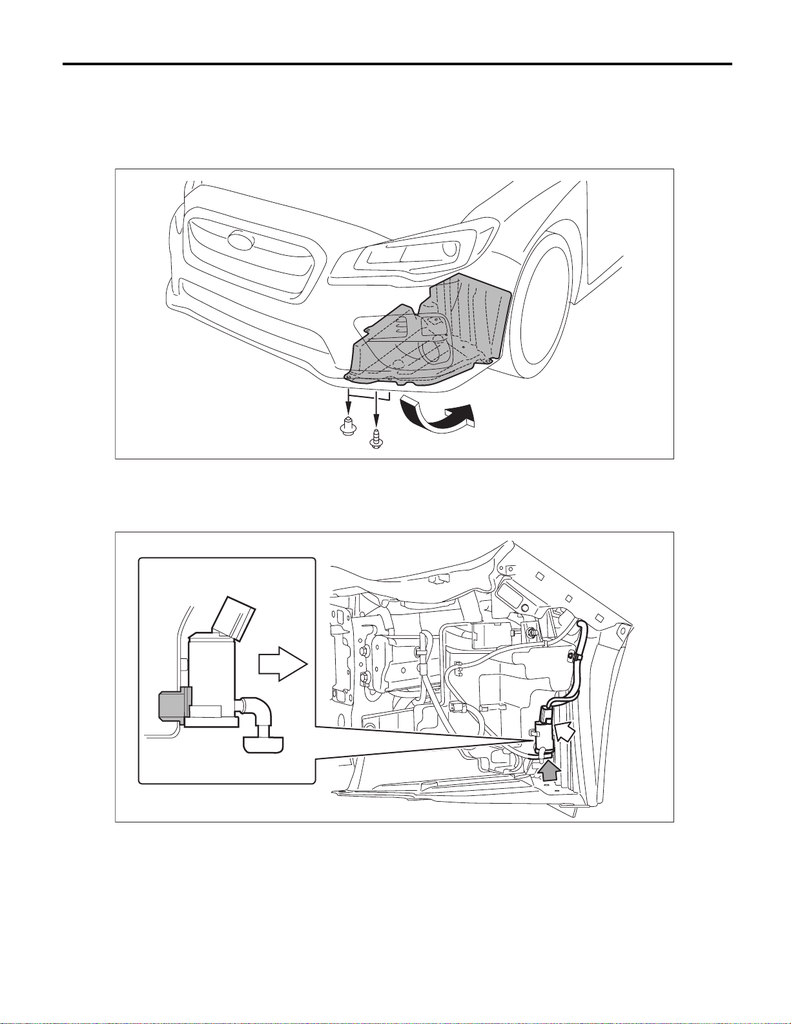

WW-15

Washer Tank and Motor

WIPER AND WASHER SYSTEMS

2. WASHER MOTOR

1) Disconnect the ground cable from battery. <Ref. to NT-5, BATTERY, NOTE, Note.>

NOTE:

For models other than STI model, disconnect the ground terminal from battery sensor.

2) Remove the clips and screws, and turn over the mud guard - front LH.

3) Disconnect the connector from the motor pump assembly - washer and remove the harness clip.

4) Prepare a container before disconnecting the hose - washer, and drain all washer fluid in the tank - wash-

er.

5) Remove the motor pump assembly - washer.

LI-01721

WW-01190

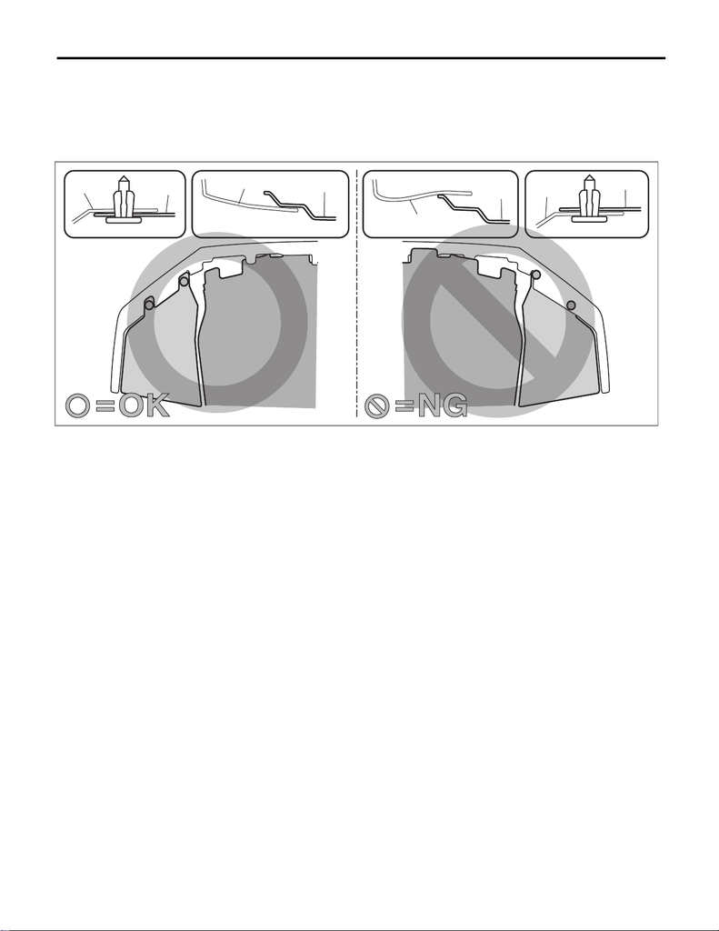

WW-16

Washer Tank and Motor

WIPER AND WASHER SYSTEMS

B: INSTALLATION

1. WASHER TANK

CAUTION:

• Install so that the front end of the under cover (b) comes inside the bumper face - front (a), and the

front end of the mud guard (c) comes outside the bumper face - front (a).

• Before installing the bumper face, match the claws on the bracket - front bumper with the engaging

position of flange section on the bumper face side. If the engaging position is not correct, the flange

section may be broken or the clearance between fender panel and bumper face may not be uniform.

1) Install the tank - washer assembly.

Tightening torque:

6 N·m (0.6 kgf-m, 4.4 ft-lb)

2) Connect the hose - washer.

3) Connect each connector and install the harness clip.

4) Install the mud guard - front.

5) Install the bumper face - front. <Ref. to EI-34, INSTALLATION, Front Bumper.>

6) Connect the battery ground terminal. <Ref. to NT-5, BATTERY, NOTE, Note.>

NOTE:

For models other than STI model, connect the ground terminal to battery sensor.

7) Add new washer fluid.

8) Adjust the fog light beam. (Model with fog light) <Ref. to LI-43, FOG LIGHT AIMING, ADJUSTMENT, Front

Fog Light Assembly.>

COM00138

(a)

(c)

(b)

(a)

(a)

(c)

(b)

(a)

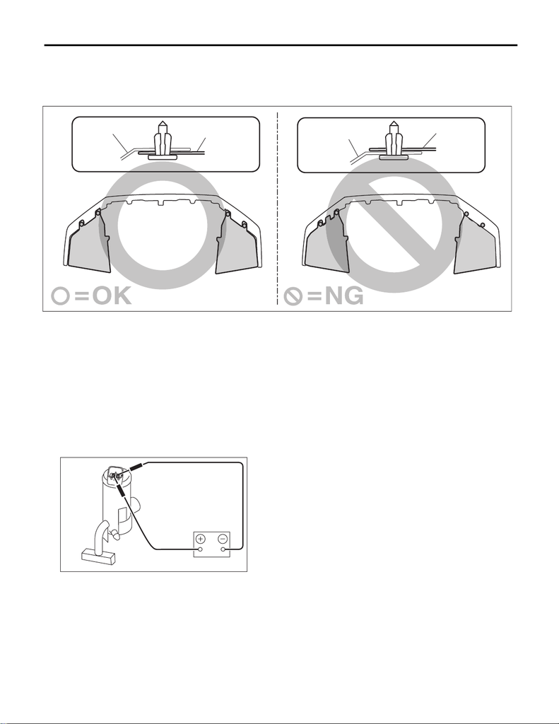

WW-17

Washer Tank and Motor

WIPER AND WASHER SYSTEMS

2. WASHER MOTOR

CAUTION:

Install the mud guard - front so that the front end of the mud guard (b) comes outside the bumper

face - front (a).

1) Install the motor pump assembly - washer to the tank - washer.

2) Connect the hose - washer.

3) Connect each connector and install the harness clip.

4) Install the mud guard - front LH.

5) Add new washer fluid.

6) Adjust the fog light beam. (Model with fog light) <Ref. to LI-43, FOG LIGHT AIMING, ADJUSTMENT, Front

Fog Light Assembly.>

C: INSPECTION

1. WASHER PUMP

Apply battery voltage to the connector terminal of the motor pump assembly - washer, and make sure that the

motor operates.

COM00136

(a)

(b)

(a)

(b)

WW-01051

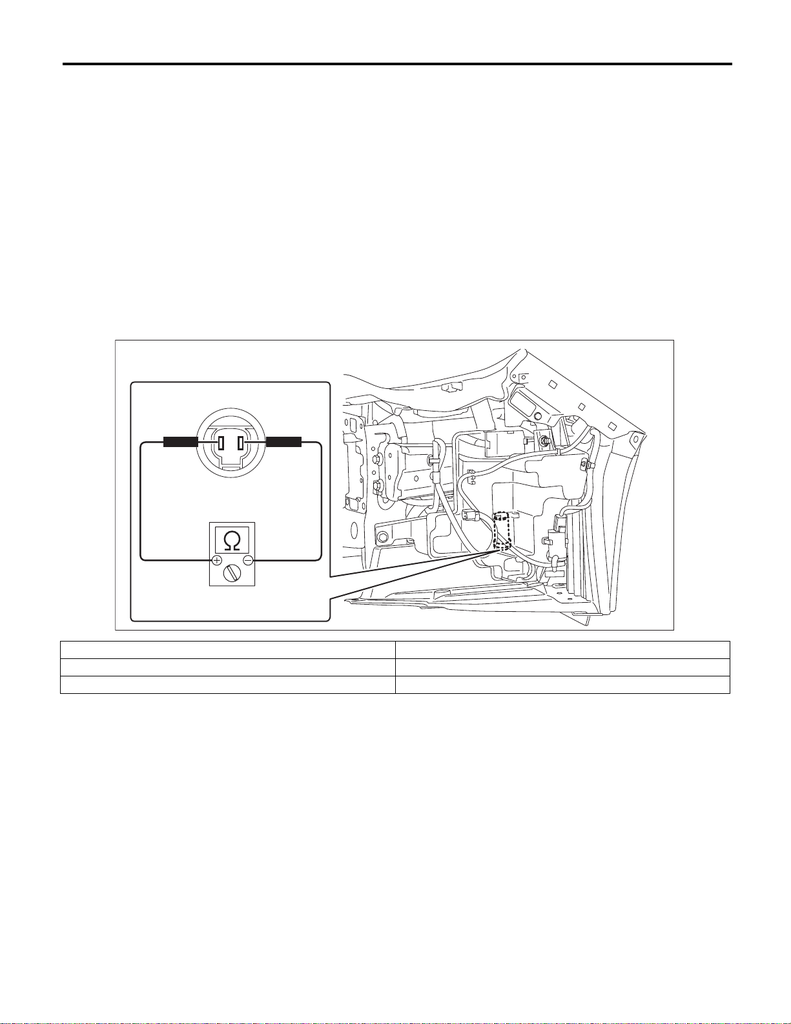

WW-18

Washer Tank and Motor

WIPER AND WASHER SYSTEMS

2. WASHER FLUID LEVEL SENSOR

1) Check the connection status of washer fluid level sensor connector.

2) Does the low washer fluid warning light illuminate after draining the washer fluid? And does the low washer

fluid warning light go off after refilling the washer fluid?

• Yes → Normal operation.

• No → Perform step 3.

3) Using a tester, measure the voltage of the washer fluid level sensor connector.

(1) Is the voltage approx. 8.5 V or more?

• Yes → Perform step 4.

• No → Check harness, meter and integrated unit, and replace if necessary.

4) Does the meter indicator illuminate if you short the washer fluid level sensor connector?

• Yes → Perform step 5.

• No → Check meter and integrated unit, and replace if necessary.

5) Using a tester, measure the resistance of the washer fluid level sensor.

(1) Turn over the mud guard.

(2) Measure the resistance of the washer fluid level sensor.

(3) Is the resistance within the standard?

• Yes → Normal operation.

• No → Replace the washer fluid level sensor along with the washer tank.

Amount of washer fluid in the tank Standard

No remaining quantity (ON) Less than 10 Ω

There is remaining quantity (OFF) 1 MΩ or more

WW-01191